# SQ 010_prob

## Shared Qs (010_prob)

#### Question

1. In a deck of strange cards, there are 349 cards. Each card has an image and a color.

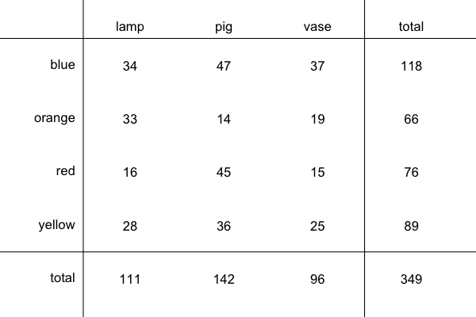

   1. What is the probability a random card is a pig?
   2. What is the probability a random card is blue?
   3. What is the probability a random card is both a pig and yellow?
   4. What is the probability a random card is either a vase or red (or both)?
   5. What is the probability a random card is red given it is a vase?
   6. What is the probability a random card is a pig given it is red?
   7. Between a lamp and a vase, which is more likely to be a red?

#### Question

2. In a deck of strange cards, there are 263 cards. Each card has an image and a color.

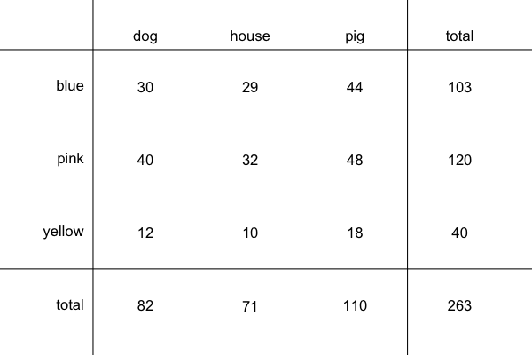

   1. What is the probability a random card is a dog?
   2. What is the probability a random card is yellow?
   3. What is the probability a random card is both a house and yellow?
   4. What is the probability a random card is either a dog or yellow (or both)?
   5. What is the probability a random card is yellow given it is a pig?
   6. What is the probability a random card is a house given it is yellow?
   7. Between a dog and a house, which is more likely to be a pink?

#### Question

3. In a deck of strange cards, there are 441 cards. Each card has an image and a color.

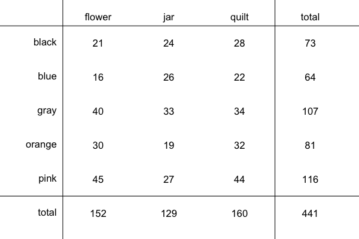

   1. What is the probability a random card is a flower?
   2. What is the probability a random card is a jar given it is pink?
   3. What is the probability a random card is either a quilt or black (or both)?
   4. What is the probability a random card is blue?
   5. What is the probability a random card is both a flower and pink?
   6. What is the probability a random card is black given it is a flower?
   7. Between a flower and a quilt, which is more likely to be a blue?

#### Question

4. In a deck of strange cards, there are 454 cards. Each card has an image and a color.

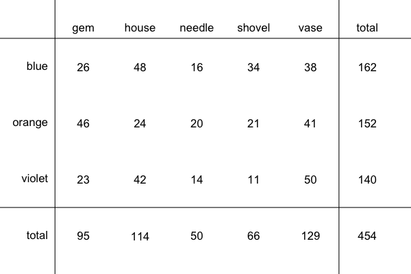

   1. What is the probability a random card is blue given it is a gem?
   2. What is the probability a random card is blue?
   3. What is the probability a random card is a house given it is violet?
   4. What is the probability a random card is a needle?
   5. What is the probability a random card is either a shovel or violet (or both)?
   6. Between a house and a shovel, which is more likely to be a blue?
   7. What is the probability a random card is both a shovel and violet?

#### Question

5. Cindy has two games today. Each game she will either win or lose. She has a 0.62 chance of winning the first game and a 0.35 chance of winning the second game.
   1. What is the chance Cindy wins both games?
   2. What is the chance Cindy loses both games?
   3. What is the chance Cindy wins once and loses once (in either order)?

#### Question

6. Cindy has two games today. Each game she will either win or lose. She has a 0.75 chance of winning the first game and a 0.37 chance of winning the second game.
   1. What is the chance Cindy wins both games?
   2. What is the chance Cindy loses both games?
   3. What is the chance Cindy wins once and loses once (in either order)?

#### Question

7. Bob has a 0.63 chance of winning a game. If Bob wins, he has a 0.89 chance of being happy after the game. If Bob loses, he has a 0.31 chance of being happy after the game.

   After the game, you notice Bob is happy. What is the probability that Bob won his game? (Do not answer as a percentage; answer as a decimal.)

#### Question

8. Bob has a 0.41 chance of winning a game. If Bob wins, he has a 0.49 chance of being happy after the game. If Bob loses, he has a 0.16 chance of being happy after the game.

   After the game, you notice Bob is happy. What is the probability that Bob won his game? (Do not answer as a percentage; answer as a decimal.)